# Prob Stats Homework 3

## Author

Tantatorn Suksangwarn 61010402

## Problem

Example 7.14 Assume that in a digital communication channel, the number of bits received in error can be modeled by a binomial random variable, and assume that the probability that a bit is received in error is 1 × 10 − 5 . If 16 million bits are transmitted, what is the probability that 150 or fewer errors occur? Let the random variable X denote the number of errors. Then X is a binomial random variable and
$$\begin{equation*}
P(X\leq150) = \sum_{x=0}^{150}{16000000 \choose x} (10^{-5})^x (1-10^{-5})^{ 16000000-x}
\end{equation*}$$
Practical Interpretation: Clearly, this probability is difficult to compute. Fortunately, the normal distribution can be used to provide an excellent approximation in this example. ## Solution

### Way I

Calculate the probability by using loop dbinom is R builtin function for compute binomial distribution

```r
binomial_result <- 0
p <- 0.00001

for (i in 0:150){
   binomial_result <- binomial_result + dbinom(i,size = 16000000,p)
}
print(binomial_result)
```

```
[1] 0.2280311
```

### Way II

Calculate by using Normal Approximation Find the Z-Score of X=0 and X=150
$$\begin{equation*}
Z = {{X-np} \over {\sqrt{np(1-p)}}}
\end{equation*}$$

```r
avg = 16000000*p
z_score_a <- -avg/(sqrt(avg*(1-p)))
z_score_b <- (150-avg)/(sqrt(avg*(1-p)))
print(z_score_a)
```

```
[1] -12.64917
```

```r
print(z_score_b)
```

```
[1] -0.7905734
```

Let’s use normal approximation
$$\begin{equation*}
P(X\le150) = \phi(-0.7906) - \phi(-12.6492)
\end{equation*}$$
pnorm is R builtin function for compute normal distribution

```r
norm_result <- pnorm(c(z_score_b))-pnorm(c(z_score_a))
print(norm_result)
```

```
[1] 0.2145965
```

## Comparison

Let’s compare both results

```r
result <- c(binomial_result,norm_result)
names(result) <- c("Binomial distribution","Normal approximation")
print(result)
```

```
Binomial distribution  Normal approximation
            0.2280311             0.2145965
```

At last, let’s draw some graph to compare both First, Let’s try binomial distribution

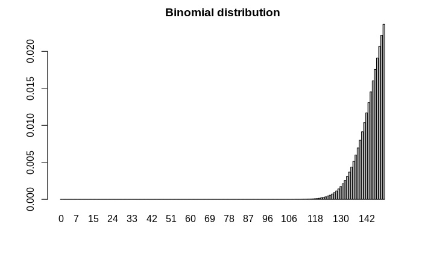

```r
x <- dbinom(0:150,size=16000000,prob=p)
barplot(x,names.arg=0:150,main="Binomial distribution")
```

Last, Let’s try out normal distribution

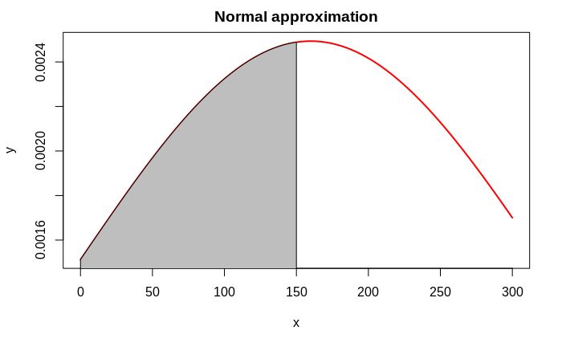

```r
x=seq(0,300,length=100)
y=dnorm(x,mean=avg,sd=avg*(1-p))
plot(x,y,type="l",lwd=2,col="red",main="Normal approximation")
x=seq(0,150,length=100)
y=dnorm(x,mean=avg,sd=avg*(1-p))
polygon(c(0,x,150),c(0,y,0),col="gray")
```